# Bitcoin Market

Binod Jung Bogati

7/20/2018

# 1. Getting the data from web

First, we will load the data from the [coinmarketcap API](https://api.coinmarketcap.com/) and display it in the output.

```r
# set working directory
setwd("/home/bjungbogati/Desktop/DataSansar/Projects/bitcoin_market")

# import json data from web
library(jsonlite)
library(httr)

json_data <- fromJSON("https://api.coinmarketcap.com/v1/ticker")

# write.csv(json_data, file="crypcoins.csv", row.names=FALSE)

# create table with top 3 rows with 8 columns
library(knitr)
kable(head(json_data, 3)[1:8])
```

| id | name | symbol | rank | price_usd | price_btc | 24h_volume_usd | market_cap_usd |
| --- | --- | --- | --- | --- | --- | --- | --- |
| bitcoin | Bitcoin | BTC | 1 | 7482.44 | 1.0 | 3398960000.0 | 128427290733 |
| ethereum | Ethereum | ETH | 2 | 468.849 | 0.0628978 | 1324600000.0 | 47283293478.0 |
| ripple | XRP | XRP | 3 | 0.454997 | 0.00006097 | 144148000.0 | 17888518035.0 |

# 2. Working with a reproducible dataset

The above data is limited and changes on daily basis, so we work with a particular dataset which is reproducible. Here, we use data from coinmarketcap.com dated on Dec 6, 2017.

```r
# read the datasets
dec6 <- read.csv("./datasets/coinmarketcap_06122017.csv", stringsAsFactors = F)

# selecting the 'id' and 'market_cap_usd' columns
market_cap_raw <- dec6[c('id', 'market_cap_usd')]

# counting row and missing values

nrow(market_cap_raw) # 1326 - total rows
```

```
## [1] 1326
```

```r
sum(is.na(market_cap_raw)) # 295 - missing value
```

```
## [1] 295
```

# 3. Discard the cryptocurrencies without a market capitalization

From above we find, market_cap_usd have 295 missing values. Here, we don’t deal with the cryptocurrency which don’t have market capitalization.

```r
# filter out the rows without a market capitalization

cap = na.omit(market_cap_raw)
nrow(cap)
```

```
## [1] 1031
```

# 4. How big is Bitcoin compared with the rest of the currencies ?

Bitcoin is under heavy competition with other competitors. Still, it’s dominant in market capitalization. Now, we compare the top 10 coins with their market share.

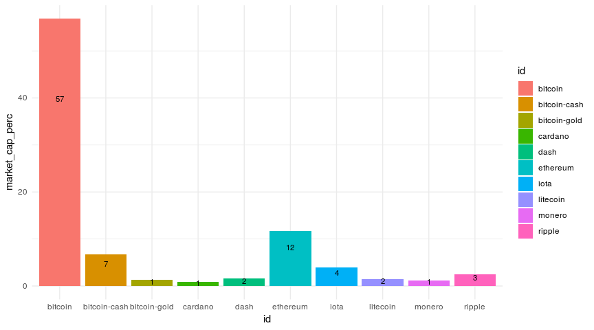

```r
# used in the plots below
top_cap_title <- "Top 10 market capitalization"
top_cap_ylabel <- "% of total cap"

# select first 10 rows and set the index
cap10 <- head(cap, 10)
rownames(cap10) <- NULL

# calculate market_cap_perc
library(dplyr)
cap10 <- cap10 %>%
  mutate(market_cap_perc = market_cap_usd/sum(cap['market_cap_usd'])*100)

total_market_cap <- round(sum(cap$market_cap_usd)/ 100000000)

library(ggplot2)

ggplot(cap10, aes(x = id, y = market_cap_perc, fill = id)) +
  geom_bar(stat = "identity", position = 'dodge') +
  geom_text(aes(label = round(market_cap_perc)), position = position_stack(vjust = 0.7), size = 3) +
  theme(plot.title = element_text(hjust = 0.5)) +
  theme_minimal()
```